# Question

Se ha entrevistado a 48 adolescentes sobre los géneros musicales que escuchan.

- 20 de ellos escuchan Cumbia,
- 20 escuchan Tango, y
- 21 Vallenato.

Además sabemos que

- 4 de ellos escuchan solamente Cumbia y Tango,
- 9 escuchan Cumbia y Vallenato, y
- 4 Tango y Vallenato.

Por último sabemos que solamente 2 escuchan los tres géneros musicales.

Considerando esa información:

## Answerlist

- ¿Cuántas personas escuchan exactamente dos géneros musicales?
- ¿Cuál es el total de personas que escuchan máximo dos géneros musicales?
- ¿Cuál es el total de personas que escuchan máximo tres géneros musicales?
- ¿Cuántos adolescentes disfrutan únicamente de Cumbia y Vallenato?

# Solution

Para resolver este problema, analizamos el diagrama de Venn que representa la intersección de los tres conjuntos: Cumbia, Tango y Vallenato.

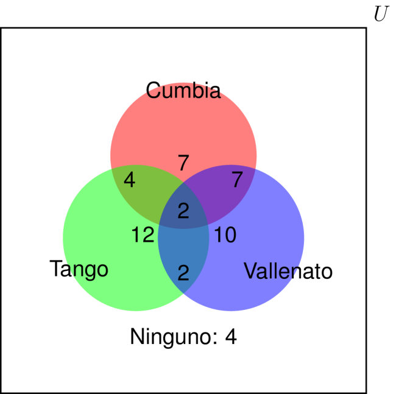

Explicación detallada:

1. ¿Cuántas personas escuchan exactamente dos géneros musicales?: 13
2. ¿Cuál es el total de personas que escuchan máximo dos géneros musicales?: 46
3. ¿Cuál es el total de personas que escuchan máximo tres géneros musicales?: 48
4. ¿Cuántos adolescentes disfrutan únicamente de Cumbia y Vallenato?: 7

## Answerlist

- La respuesta es 13.
- La respuesta es 46.
- La respuesta es 48.
- La respuesta es 7.

# Meta-information

exname: Géneros musicales  
extype: cloze  
exclozetype: num|num|num|num  
exsolution: 13|46|48|7  
extol: 0  
exsection: Diagrama de Venn